# XT 2007a effect sizes and power analysis (for XTMEM1)

Molly Lewis

2016-12-05

To estimate the effect size, assume the critical difference is selections of basic level objects in the 1 vs. 3 subordinate example conditions. Each participant saw 1 trial of each type for three different semantic domains (vehicles, veggies, animals). On each trial, there were 2 basic level exemplars that the participant could select. Thus, for each trial type (1 vs. 3), each participant could select a maximum of 6 basic level objects across the entire experiment. XT and SPSS then compared the total number of basic level selections across participants in the two conditions, using a BETWEEN-subject t-test. Note, however, that this is anti-conservative because it doesn’t take into acount the independence between responses for the same participant.

Here we pool across these experiments to estimate the overall effect size and estimate sample size for desired power in XTMEM1.

Data from all three experiments from SPSS11, table 1. Note that we don’t have SDs for XT data and so we estimate these values to be the same as SPSS11.

```r
df = data.frame(exp = c("XT_adults_e1", "XT_children_e2", "SPSS_adults_e1"),
                   one_means = c( 76, 40, 48.24),
                   three_means = c(9, 6, 10.53),
                   one_sd = c(40.40, 40.40, 40.40),
                   three_sd = c(24.97, 24.97, 24.97),
                   n = c(22, 36, 19))
kable(df)
```

| exp | one_means | three_means | one_sd | three_sd | n |
| --- | --- | --- | --- | --- | --- |
| XT_adults_e1 | 76.00 | 9.00 | 40.4 | 24.97 | 22 |
| XT_children_e2 | 40.00 | 6.00 | 40.4 | 24.97 | 36 |
| SPSS_adults_e1 | 48.24 | 10.53 | 40.4 | 24.97 | 19 |

We calculate the overall effect size using a random effect meta-analytic model.

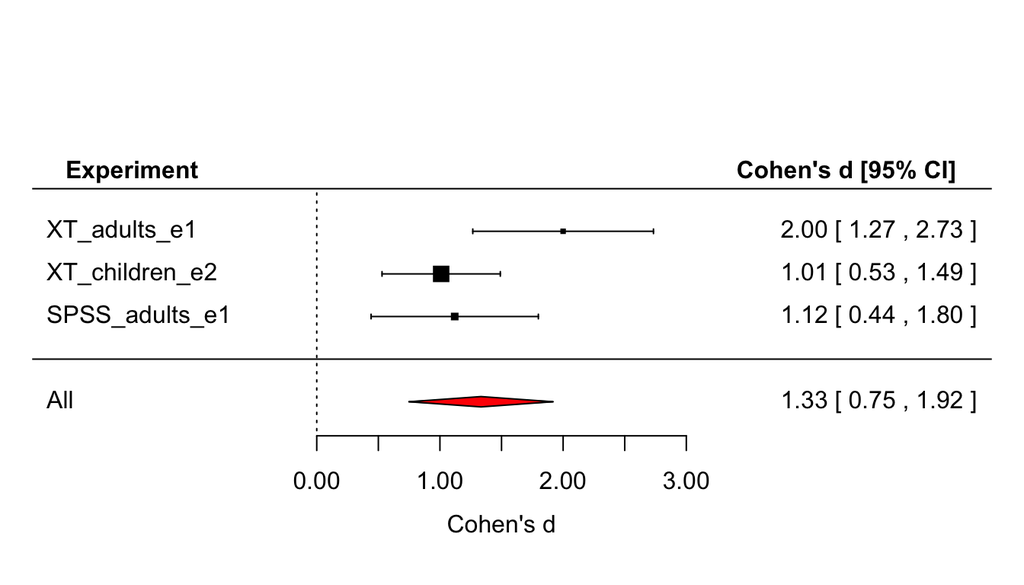

```r
df$d = mes(df$one_means, df$three_means, df$one_sd,
       df$three_sd, df$n, df$n, verbose = F)$d

df$d_var = mes(df$one_means, df$three_means, df$one_sd,
       df$three_sd, df$n, df$n, verbose = F)$var.d

model = rma(d, d_var, data = df)

par(cex = 1, font = 1)
forest(model,
       slab = df$exp,
       mlab = "All",
       xlab = "Cohen's d")
par(font = 2)
text(-1.5, 4.4, "Experiment")
text(4.3, 4.4, "Cohen's d [95% CI]")

addpoly(model, row = -1, cex = .75,
        annotate = F,  col = "red", mlab = "", efac = 2)
```

Calculate power with t-test, using the above estimate of effect size.

```r
desired.power <- .99

p.t.two <- pwr.t.test(d = model$b,
                      power = desired.power,
                      type = "two.sample",
                      alternative = "two.sided")

p.t.two
```

```
##
##      Two-sample t test power calculation
##
##               n = 21.68692
##               d = 1.333243
##       sig.level = 0.05
##           power = 0.99
##     alternative = two.sided
##
## NOTE: n is number in *each* group
```

For nearly perfect power, would need 22 independent observations. So, 22 people? But, given the t-test isn’t really the right statistical analysis should we run 50 to be conservative?